# Notebook for NLP Capstone Project

#### sentences is a list over sentences, split into words

```python
sentences = []
for punkt_sentence in punkt_sentences:
    if len(punkt_sentence) > 0:
        sentences.append(sentence_to_wordlist(punkt_sentence))
```

```python
sentences[5678]
```

```
['when',
 'we',
 'get',
 'to',
 'the',
 'moon',
 'what',
 'shall',
 'we',
 'do',
 'there']
```

```python
alice_sent = []
for alice_sentence in alice_sentences:
    if len(alice_sentence) > 0:
        alice_sent.append(sentence_to_wordlist(alice_sentence))
```

```python
len(alice_sent), len(alice_fin_sent)
```

```
(639, 639)
```

#### sentence_to_cleanlist cleans sentences but does not split sentence into a list of words

```python
clean_sentences = []
for punkt_sentence in punkt_sentences:
    if len(punkt_sentence) > 0:
        #clean_sentences.append(sentence_to_cleanlist(punkt_sentence))
        clean_sentences.append(sentence_to_wordlist(punkt_sentence))
```

```python
len(clean_sentences)
```

```
309218
```

```python
clean_sentences[181], punkt_sentences[181]
```

```
(['ah',
  'i',
  'wish',
  'i',
  'had',
  'inherited',
  'many',
  'of',
  'papa',
  's',
  'qualities'],
 "Ah, I wish I had inherited many of papa's qualities.")
```

```python
wordlist=sentence_to_wordlist(corpus_raw)
```

```python
len(wordlist)
```

```
5572533
```

```python
alice_clean_sentences = []
for alice_sentence in alice_sentences:
    if len(alice_sentence) > 0:
        alice_clean_sentences.append(sentence_to_wordlist(alice_sentence))
```

```python
alice_sentences[88], alice_clean_sentences[88]
```

```
('she thought.', ['she', 'thought'])
```

```python
len(clean_sentences)
```

```
309218
```

```python
print('Standard tokenization: ', raw_sent[93])
print('Punkt tokenization:', punkt_sentences[93])
print('Cleaned sentences:', clean_sentences[93])
print('Split sentences:', sentences[93])
print('Removed stopwords:', all_fin_sent[93])
```

```
Standard tokenization:  No debt, no borrowing.
Punkt tokenization: No debt, no borrowing.
Cleaned sentences: ['no', 'debt', 'no', 'borrowing']
Split sentences: ['no', 'debt', 'no', 'borrowing']
Removed stopwords: ['debt', 'borrowing']
```

```python
corpus_tok= word_tokenize(corpus_raw)
```

```python
len(corpus_tok)
```

```
6601613
```

```python
vocab=set(corpus_tok)
len(vocab)
```

```
96909
```

```python
word_tok_sent=[]
sumwords = 0
for s in raw_sent:
    word_tok_sent.append(word_tokenize(s))
```

```python
len(word_tok_sent)
```

```
309218
```

```python
len(corpus_raw), len(alice_corpus), len(gulliver_corpus)
```

```
(30776216, 53690, 581131)
```

```python
#Wordlist lenght - number of 'clean' words
wordlist=sentence_to_wordlist(corpus_raw)
```

```python
#wordlist
```

```python
#wordlist=sentence_to_wordlist(corpus_raw)
print('Corpus_raw:', len(corpus_raw))
print('Wordlist:', len(wordlist))
print('Sentences:', len(sentences))
print('Vocab:', len(vocab))
```

```
Corpus_raw: 30776216
Wordlist: 5572533
Sentences: 309218
Vocab: 96909
```

### FreqDist for the tokens from corpus_raw returns single characters as the most frequent words

```python
fdist = FreqDist()
for sentence in nltk.tokenize.sent_tokenize(corpus_raw):
    for word in nltk.tokenize.word_tokenize(sentence):
        fdist[word] += 1
```

```python
fdist
```

```
FreqDist({',': 460770, 'the': 270580, '.': 258286, 'and': 160660, 'of': 143300, 'to': 142159, 'a': 95923, 'I': 91671, 'in': 78754, 'that': 71929, ...})
```

### FreqDist for the 'cleaned' sentences returns another list; real words

```python
fdist_sent = FreqDist()
for sentence in sentences:
    for word in sentence:
        fdist_sent[word] += 1
```

```python
fdist_sent
```

```
FreqDist({'the': 295365, 'and': 180803, 'to': 150001, 'of': 147050, 'a': 102267, 'i': 93313, 'in': 84629, 'that': 79079, 'he': 78451, 'it': 63210, ...})
```

```python
fdist_all_fin_sent = FreqDist()
for sentence in all_fin_sent:
    for word in sentence:
        fdist_all_fin_sent[word] += 1
```

### When testing on the sentences where stopwords are removed, the list is even better

```python
fdist_all_fin_sent
```

```
FreqDist({'said': 19002, 'one': 17770, 'would': 16988, 'man': 11403, 'could': 11012, 'upon': 9785, 'well': 9206, 'time': 9037, 'know': 8780, 'thou': 8765, ...})
```

```python
fdist_fin_alice = FreqDist()
for sentence in alice_fin_sent:
    for word in sentence:
        fdist_fin_alice[word] += 1
```

```python
fdist_fin_alice
```

```
FreqDist({'alice': 173, 'said': 144, 'little': 59, 'rabbit': 37, 'one': 35, 'like': 34, 'queen': 30, 'could': 28, 'mouse': 27, 'illustration': 26, ...})
```

```python
fdist_fin_mow = FreqDist()
for sentence in mow_fin_sent:
    for word in sentence:
        fdist_fin_mow[word] += 1
```

```python
fdist_fin_mow
```

```
FreqDist({'said': 430, 'little': 231, 'mowgli': 220, 'man': 177, 'one': 174, 'would': 162, 'jungle': 147, 'head': 137, 'bagheera': 129, 'could': 125, ...})
```

```python
#raw_words=nltk.tokenize.word_tokenize(raw_sentences)
```

```python
fdist_all_fin_sent.most_common(10)
```

```
[('said', 19002),
 ('one', 17770),
 ('would', 16988),
 ('man', 11403),
 ('could', 11012),
 ('upon', 9785),
 ('well', 9206),
 ('time', 9037),
 ('know', 8780),
 ('thou', 8765)]
```

```python
fdist_fin_alice.most_common(10)
```

```
[('alice', 173),
 ('said', 144),
 ('little', 59),
 ('rabbit', 37),
 ('one', 35),
 ('like', 34),
 ('queen', 30),
 ('could', 28),
 ('mouse', 27),
 ('illustration', 26)]
```

### FreqDist on sentences returns 'sentences', here only names

```python
fdist_clean_sentences=FreqDist(clean_sentences)
#print(fdist_sentences2)
fdist_clean_sentences
```

[output not shown]

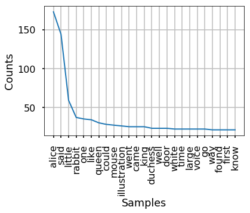

```python
fdist_fin_alice.plot(25, cumulative=False)
plt.show()
```

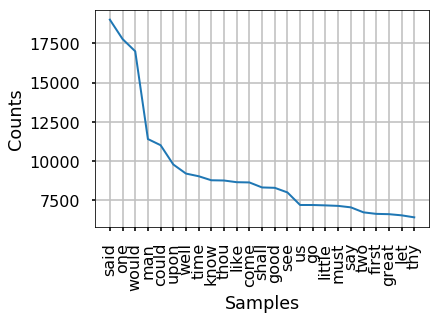

```python
fdist_all_fin_sent.plot(25, cumulative=False)
plt.show()
```

```python
fin_sent.plot(30, cumulative=False)
plt.show()
```

#### FreqDist on sentence level - does it make sense?

The most frequent sentences will often be chapter names, dialogue markers in palys - or short general word strings, as we can see below.

```python
fdist_sentences=FreqDist(punkt_sentences)
print(fdist)
fdist_sentences
```

```
<FreqDist with 96906 samples and 6601625 outcomes>
```

```
FreqDist({'HEDDA.': 533, 'ALLMERS.': 453, 'FALSTAFF.': 432, 'Nora.': 412, 'KING.': 412, 'GLOUCESTER.': 399, 'MRS. ALVING.': 337, 'HAMLET.': 334, 'RITA.': 322, 'DUKE.': 311, ...})
```

```python
fdist_sentences_gulliver=FreqDist(gulliver_sentences)
print(fdist)
fdist_sentences_gulliver
```

```
<FreqDist with 96906 samples and 6601625 outcomes>
```

```
FreqDist({'CHAPTER I.': 4, 'CHAPTER II.': 4, 'CHAPTER III.': 4, 'CHAPTER VIII.': 4, 'CHAPTER IV.': 3, 'CHAPTER VII.': 2, 'CHAPTER VI.': 2, 'CHAPTER IX.': 2, 'To return from this digression.': 2, 'CHAPTER X.': 2, ...})
```

```python
fdist_sentences_mow=FreqDist(mow_sentences)
print(fdist)
fdist_sentences_mow
```

```
<FreqDist with 96906 samples and 6601625 outcomes>
```

```
FreqDist({'Mahadeo!': 8, 'Why?': 5, 'Ho!': 4, 'All things made he--Shiva the Preserver.': 3, 'He is there.': 2, 'Come along!': 2, '“Well!': 2, 'Tricked!': 2, 'Somalo!': 2, 'Arre!': 2, ...})
```

### Pos_tag - tested but not used for the 3 main questions posed

```python
test_sentence=word_tokenize(punkt_sentences[99])
test_sentence
```

```
['Come',
 ',',
 'come',
 ',',
 'my',
 'little',
 'skylark',
 'must',
 'not',
 'droop',
 'her',
 'wings',
 '.']
```

```python
pos_tag(test_sentence)
```

```
[('Come', 'NNP'),
 (',', ','),
 ('come', 'NN'),
 (',', ','),
 ('my', 'PRP$'),
 ('little', 'JJ'),
 ('skylark', 'NN'),
 ('must', 'MD'),
 ('not', 'RB'),
 ('droop', 'VB'),
 ('her', 'PRP$'),
 ('wings', 'NNS'),
 ('.', '.')]
```

### Packing a normalization code (tokenize, lemmatize, stem , lowercase)

I made the packaged normalize function, but did not use it other that for testing

```python
norm_sents=[]
def normalize_sentences(sentence_in):
    norm_sent=[]
    for sentence in sentence_in:
        for token in nltk.tokenize.word_tokenize(sentence):
            if token not in stop_words:
               # print(token)
                token= lem.lemmatize(token).lower()
               # print(token)
                token= stem.stem(token)
               # print(token)
                norm_sents.append(token)
                print(norm_sents)
    return norm_sents
```

```python
corpus_norm=normalize_sentences(clean_sentences)
```

```python
chem_norm=normalize_sentences(chem_sentences)
```

```python
len(corpus_norm)
```

```python
#book_sents
```

```python
alice_corpus_norm=normalize_sentences(alice_clean_sentences)
```

```python
alice_corpus_norm
```

```python
print('Corpus size: ', len(corpus_raw))
print('Sentence size:', len(sentences))
print('Word size:', len(words))
print('Token size:', sum([len(sentence) for sentence in sentences]))
print('Vocab size:', len(set(words)) )
```

```
Corpus size:  30776216
Sentence size: 309218
Word size: 5574877
Token size: 5572533
Vocab size: 70927
```

### Transformation of cleaned and preprocessed corpus

#### Trying out stemming and lemming - not used in the code for answering questions

```python
ps = PorterStemmer()
ps
```

```python
lem = WordNetLemmatizer()
lem
```

```
<WordNetLemmatizer>
```

```python
stem = nltk.stem.SnowballStemmer('english')
#corpus_raw_lowcase = corpus_raw.lower()
#sentences_low=raw_sentences.lower()
```

```python
for token in nltk.word_tokenize(corpus_raw):
    stem.stem(token)
```

```python
stemmed_words=[]
for s in punkt_sentences:
    for w in word_tokenize(s):
       stemmed_words.append(stem.stem(w))
```

```python
#stemmed_words
```

```python
lemmed_words=[]
for x in stemmed_words:
    lemmed_words.append(lem.lemmatize(x))
```

```python
#lemmed_words
stemmed_words
```

### Trying out Gensim TFidf Model usage

### NB : This was a hypothesis I wanted to try out, not used in main code, left for documentation

```python
#corpus=[word_tokenize(sentence)for sentence in corpus_raw]
```

```python
#corpus = [word_tokenize(book) for book in corpus_raw]
```

```python
#lexicon = gensim.corpora.Dictionary(corpus_raw)
```

```python
#alice_text =alice_corpus_norm
```

```python
#dictionary = corpora.Dictionary(text_data).corpus_raw = [dictionary.doc2bow(text) for text in corpus_raw]
```

```python
#dictionary = [corpora.Dictionary.doc2bow(text) for text in corpus_raw]
```

```python
#alice_corpus_x=[word_tokenize(alice_sentence)for alice_sentence in alice_corpus]
```

```python
#alice_corpus_y = [word_tokenize(alice_corpus)]
```

```python
#alice_dictionary = [dictionary.doc2bow(text) for text in alice_text]
```

```python
#alice_lexicon=gensim.corpora.Dictionary(alice_fin_sent)
```

```python
print(alice_lexicon)
```

```
Dictionary(1377 unique tokens: ['alice', 'author', 'carroll', 'distributed', 'duchess']...)
```

```python
tfidf = TfidfVectorizer()
```

```python
#vectors_alice=[tfidf[alice_lexicon.doc2bow(alice_sentences)]]
```

```python
#vectors=[tfidf[dictionary.doc2bow(doc)] for doc in book_corpus]
```

```python
#vectors_alice=tfidf(doc_term_matrix_alice)
```

```python
lexicon.save_as_text('lexicon.txt', sort_by_word=True)
tfidf.save('tfidf.pkl')
```

```python
#id2word = gensim.corpora.Dictionary(tokens)
#vectorizer = CountVectorizer(binary=True)
#vectors = vectorizer.fit_transform(book_corpus)
```

```python
tfidf = TfidfVectorizer()
#tfidf_alice= TfidfVectorizer()
```

```python
vectors
```

```python
#corpus_transformed = tfidf.fit_transform(sentences)
```

```python
dist_alice = np.sum(data, axis=0)
print(dist_alice)
```

[output not shown]

```python
data=corpus_alice_tf
np.clip(data, 0, 1, out=data)
```

```
array([[0., 0., 0., ..., 0., 0., 0.],
       [0., 0., 0., ..., 0., 0., 0.],
       [0., 0., 0., ..., 0., 0., 0.],
       ...,
       [0., 0., 0., ..., 0., 0., 0.],
       [0., 0., 0., ..., 0., 0., 0.],
       [0., 0., 0., ..., 0., 0., 0.]])
```

```python
list_count=[]
list_tag=[]

for tag, count in zip(vocab, dist_alice):
    list_count.append(count)
    list_tag.append(tag)
   # print(count, tag)
    #print(list_count)
    #print(list_tag)
#    return list_count, list_tag

list=pd.DataFrame({"Count": list_count, "Tag": list_tag})
#print(list)
list.sort_values(by=['Count'], ascending=False)
#list_sorted=list.sortby('Count')
#list_sorted
```

|  | Count | Tag |
| --- | --- | --- |
| 18 | 173.0 | alic |
| 420 | 59.0 | littl |
| 572 | 37.0 | rabbit |
| 564 | 31.0 | queen |
| 426 | 31.0 | look |
| 147 | 28.0 | could |
| 360 | 27.0 | illustr |
| 464 | 27.0 | mous |
| 816 | 25.0 | voic |
| 213 | 23.0 | duchess |
| 400 | 22.0 | larg |
| 837 | 22.0 | white |
| 760 | 21.0 | thought |
| 758 | 21.0 | think |
| 757 | 21.0 | thing |
| 291 | 21.0 | found |
| 272 | 21.0 | first |
| 755 | 20.0 | there |
| 318 | 19.0 | great |
| 61 | 19.0 | began |
| 570 | 19.0 | quit |
| 458 | 18.0 | moment |
| 338 | 17.0 | heard |
| 606 | 17.0 | round |
| 305 | 16.0 | garden |
| 853 | 16.0 | would |
| 742 | 14.0 | tabl |
| 781 | 14.0 | tri |
| 790 | 14.0 | turn |
| 104 | 14.0 | caterpillar |
| ... | ... | ... |
| 391 | 1.0 | kneel |
| 392 | 1.0 | knelt |
| 394 | 1.0 | known |
| 395 | 1.0 | knuckl |
| 398 | 1.0 | lamp |
| 354 | 1.0 | housemaid |
| 399 | 1.0 | languid |
| 402 | 1.0 | largest |
| 403 | 1.0 | later |
| 404 | 1.0 | lead |
| 405 | 1.0 | leader |
| 407 | 1.0 | lean |
| 386 | 1.0 | kettl |
| 385 | 1.0 | keep |
| 383 | 1.0 | juror |
| 380 | 1.0 | join |
| 379 | 1.0 | jason |
| 378 | 1.0 | isbel |
| 377 | 1.0 | iron |
| 376 | 1.0 | inward |
| 374 | 1.0 | insult |
| 373 | 1.0 | instead |
| 371 | 1.0 | insid |
| 370 | 1.0 | inquisit |
| 366 | 1.0 | imposs |
| 363 | 1.0 | immens |
| 361 | 1.0 | imagin |
| 358 | 1.0 | hunt |
| 357 | 1.0 | humbl |
| 861 | 1.0 | zigzag |

862 rows × 2 columns

```python
#vocab=tfidf.get_feature_names()
vocab=tfidf_alice.get_feature_names()
#vocab
```

```python
#corpus_alice_tf= tfidf.fit_transform(alice_clean_sentences)
corpus_alice_tf= tfidf_alice.fit_transform(alice_corpus_norm).toarray()
```

```python
#test=list(corpus_alice_tf)
print(corpus_alice_tf)
```

```
[[0. 0. 0. ... 0. 0. 0.]
 [0. 0. 0. ... 0. 0. 0.]
 [0. 0. 0. ... 0. 0. 0.]
 ...
 [0. 0. 0. ... 0. 0. 0.]
 [0. 0. 0. ... 0. 0. 0.]
 [0. 0. 0. ... 0. 0. 0.]]
```

## Word Analysis - Define the w2v.Word2Vec object

Using Gensim for the model

```python
#  https://www.kaggle.com/c/word2vec-nlp-tutorial#part-2-word-vectors
```

### Start by defining parameters and establishing model

```python
# Word2Vec Parameters
num_features = 300
min_word_count = 15
num_workers = multiprocessing.cpu_count()
context_size = 10
downsampling = 1e-4
seed = 9
```

```python
word_model = w2v.Word2Vec(
    sg=1,
    seed=seed,
    workers=num_workers,
    size=num_features,
    min_count=min_word_count,
    window=context_size,
    sample=downsampling)
```

```python
print(word_model)
```

```
Word2Vec(vocab=0, size=300, alpha=0.025)
```

#### Build vocabulary

```python
word_model.build_vocab(sentences)
```

```python
print("model vocabulary length:", len(word_model.wv.vocab))
#len(vocab)
```

```
model vocabulary length: 14661
```

```python
print(word_model)
```

```
Word2Vec(vocab=14661, size=300, alpha=0.025)
```

#### Train model on corpus

```python
word_model.train(sentences, epochs=5,
total_examples=14661)
```

```
(12775775, 27862665)
```

```python
print(word_model)
```

```
Word2Vec(vocab=14661, size=300, alpha=0.025)
```

```python
#word_model.wv.vocab
```

```python
epochs= word_model.epochs
print(epochs)
```

```
5
```

```python
word_model.corpus_count
```

```
309218
```

```python
#word_model.train(sentences, epochs=5,
#total_examples=309218)
```

#### Create matrix from trained model

```python
all_word_vectors_matrix = word_model.wv.vectors
```

```python
all_word_vectors_matrix
```

```
array([[-0.05490553, -0.03514403,  0.22514175, ..., -0.08452054,
         0.21196866,  0.19920997],
       [ 0.01007042, -0.1477719 , -0.08091531, ..., -0.03496036,
         0.11136746,  0.14401469],
       [ 0.19860134, -0.19205412, -0.03539648, ...,  0.10789791,
         0.14991795,  0.1841636 ],
       ...,
       [ 0.08012542,  0.05427839, -0.21325646, ..., -0.21773148,
         0.03282636,  0.2429976 ],
       [ 0.12426914, -0.08070146, -0.24282086, ..., -0.20464553,
         0.12231635,  0.0990601 ],
       [-0.1321053 , -0.03550019,  0.03718087, ..., -0.19634509,
         0.05690835,  0.16387962]], dtype=float32)
```

```python
all_word_vectors_matrix.shape
```

```
(14661, 300)
```

### Use TSNE to reduce all_word_vectors_matrix to 2 dimensions.

```python
tsne = sklearn.manifold.TSNE(n_components = 2,
                             early_exaggeration = 6,
                             learning_rate = 500,
                             n_iter = 300,
                             random_state = 2)
```

```python
print(word_model)
```

```
Word2Vec(vocab=14661, size=300, alpha=0.025)
```

```python
all_word_vectors_matrix_2dim = tsne.fit_transform(all_word_vectors_matrix)
```

```python
all_word_vectors_matrix_2dim.shape
```

```
(14661, 2)
```

```python
max=all_word_vectors_matrix_2dim
```

```python
with open(r"word_matrix_2d.pickle", "wb") as output_file:
    pickle.dump(max, output_file)
```

```python
max
```

```
array([[ 1.3471783 ,  2.2832406 ],
       [ 0.918422  ,  2.0255618 ],
       [-1.1415077 ,  1.9775717 ],
       ...,
       [ 6.8104887 , -1.039832  ],
       [ 0.04909876, -1.3136746 ],
       [-0.6327323 , -1.5622499 ]], dtype=float32)
```

#### Create a dataframe to record each word and its coordinates.

```python
points = pd.DataFrame(
    [(word, coords[0], coords[1])
        for word, coords in [
            (word, all_word_vectors_matrix_2dim[word_model.wv.vocab[word].index])
            for word in word_model.wv.vocab
        ]],
    columns=["word", "x", "y"])
```

#### Preview the points

```python
points[250:260]
```

|  | word | x | y |
| --- | --- | --- | --- |
| 250 | due | -6.891693 | -0.326071 |
| 251 | pooh | -1.209189 | -0.872126 |
| 252 | borrow | -5.021657 | -4.933436 |
| 253 | up | 4.961055 | 0.159234 |
| 254 | ear | 1.187850 | -4.219483 |
| 255 | suppose | -2.472252 | -1.662486 |
| 256 | borrowed | -0.955885 | 9.339765 |
| 257 | fifty | -0.092562 | 10.451357 |
| 258 | pounds | -0.552730 | 10.249588 |
| 259 | today | -0.121838 | -1.257497 |

### Display the layout of all of the points.

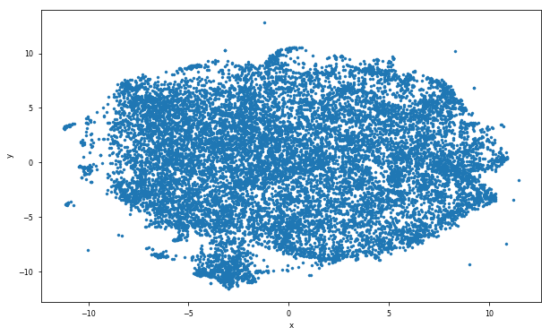

```python
sns.set_context("paper")
points.plot.scatter("x", "y", s=10, figsize=(10, 6))
```

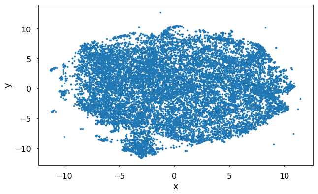

```python
sns.set_context("poster")
points.plot.scatter("x", "y", s=10, figsize=(10, 6))
```

### Look for vector-based similarities

```python
word_model.wv.most_similar("king")
```

```python
word_model.wv.most_similar('science')
```

```
[('definition', 0.7783334255218506),
 ('theory', 0.7772616147994995),
 ('biology', 0.774417519569397),
 ('logic', 0.7701702117919922),
 ('problems', 0.7659088373184204),
 ('ethics', 0.7631567716598511),
 ('scientists', 0.7616223096847534),
 ('scientific', 0.7577517032623291),
 ('astronomy', 0.7561200857162476),
 ('mathematics', 0.7533454895019531)]
```

#### Test for 'not similar* (oddities )

```python
word_model.wv.doesnt_match("snake tiger cat man lion ape elephant dog ".split())
```

```
'man'
```

#### Plot a limited region with points

```python
def plot_region(x_bounds, y_bounds):

    slice = points[(x_bounds[0] <= points.x) & (points.x <= x_bounds[1]) &
                   (y_bounds[0] <= points.y) & (points.y <= y_bounds[1])]

    ax = slice.plot.scatter("x", "y", s=35, figsize=(10, 6))
    for i, point in slice.iterrows():
        ax.text(point.x + 0.005, point.y + 0.005, point.word, fontsize=11)
```

```python
points[points.word == 'moon']
```

|  | word | x | y |
| --- | --- | --- | --- |
| 2824 | moon | 8.16965 | 6.654867 |

```python
points[points.word == 'tarzan']
```

|  | word | x | y |
| --- | --- | --- | --- |
| 13005 | tarzan | 10.917833 | 0.420028 |

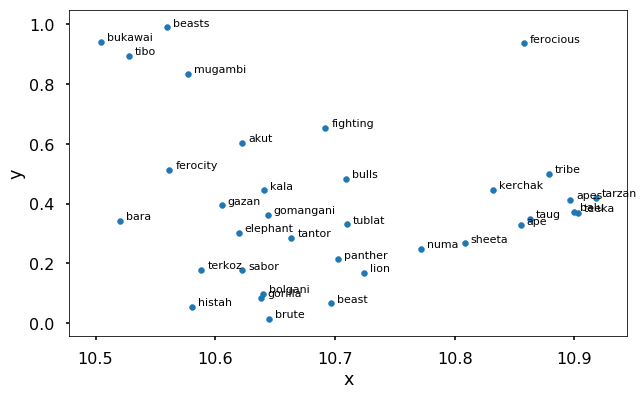

```python
plot_region(x_bounds=(10.5, 11.5), y_bounds=(0.0, 1.0))
```

```python
word_model.wv.most_similar("hunger")
```

```
[('thirst', 0.759745717048645),
 ('blooded', 0.6756629347801208),
 ('pangs', 0.6752413511276245),
 ('raw', 0.6597349643707275),
 ('gnawing', 0.6590057611465454),
 ('famine', 0.6581816673278809),
 ('craving', 0.649341881275177),
 ('starved', 0.6485166549682617),
 ('eaters', 0.6474582552909851),
 ('ravenous', 0.6468689441680908)]
```

#### Find 'word pairs' completing a shown relationship.

```python
def nearest_similarity_cosmul(start1, end1, start2):

    similarities = word_model.wv.most_similar_cosmul(
        positive=[start1, start2],
        negative=[end1])
    end2 = similarities[0][0]
    print("{start1} is related to {end1}, as {start2} is related to {end2}".format(**locals()))
    return end2
```

```python
nearest_similarity_cosmul("man", "woman", "queen")
nearest_similarity_cosmul("husband", "wife", "man")
nearest_similarity_cosmul("swann", "odette", "artagnan")
nearest_similarity_cosmul("sea", "boat", "city")
```

```
man is related to woman, as queen is related to king
husband is related to wife, as man is related to woman
swann is related to odette, as artagnan is related to porthos
sea is related to boat, as city is related to palaces
```

```
'palaces'
```

## Doc2Vec for book comparisons

```python
# Read and tag each book into book_corpus
book_corpus = []
for book_filename in book_filenames:
    with codecs.open(book_filename, "r", "utf-8") as book_file:
        book_corpus.append(
            gensim.models.doc2vec.TaggedDocument(
                gensim.utils.simple_preprocess( # Clean the text with simple_preprocess
                    book_file.read()),
                    ["{}".format(book_filename)])) # Tag each book with its filename
```

```python
len(book_corpus)
```

```
41
```

#### Establish a model from Doc2Vec

```python
model_doc = gensim.models.Doc2Vec(vector_size = 200,
                              min_count = 15,
                              epochs = 20)
```

```python
model_doc.build_vocab(book_corpus)
print("model's vocabulary length:", len(model_doc.wv.vocab))
```

```
model's vocabulary length: 14539
```

```python
num=model_doc.corpus_count
num
```

```
41
```

```python
print(model_doc)
```

```
Doc2Vec(dm/m,d200,n5,w5,mc15,s0.001,t3)
```

```python
epoch=model_doc.epochs
print(epoch)
```

[output not shown]

```python
model_doc.train(book_corpus, total_examples=14539, epochs=20)
```

### Find the most similar book for each book

```python
for book in book_filenames:
    most_similar = model_doc.docvecs.most_similar(book)[0][0]
    print("{} - {}".format(book, most_similar))
```

```
Books\A_Dolls_house_Ibsen.rtf - Books\Ghosts_Ibsen.rtf
Books\Alice_in_Wonderland.rtf - Books\Norwegian_tales_Asbjornsen_Moe.rtf
Books\All_around_the_moon_Verne.rtf - Books\The_secret_of_the_island_verne.rtf
Books\An_archtartic_mystery_verne.rtf - Books\The_secret_of_the_island_verne.rtf
Books\Anthem_Rand.rtf - Books\The_jungle_book_Kipling.rtf
Books\Around_the_world_in_80_days_Verne.rtf - Books\Pride_and_Prejudices .rtf
Books\Don_Quixote.rtf - Books\Iliad_Homer.rtf
Books\Fairytales_H_C_Andersen.rtf - Books\Norwegian_tales_Asbjornsen_Moe.rtf
Books\Ghosts_Ibsen.rtf - Books\Hedda_Gabler_Ibsen .rtf
Books\Great_Expectations_by_Charles_Dickens.rtf - Books\Tale_of_two_cities_dickens.rtf
Books\Gullivers_Travels_Defoe.rtf - Books\Robinson_Crusoe _ Defoe.rtf
Books\Hedda_Gabler_Ibsen .rtf - Books\LIttle_Eyolf_Ibsen.rtf
Books\Iliad_Homer.rtf - Books\Don_Quixote.rtf
Books\Jungle_tales_of_Tarzan.rtf - Books\The_beasts_of_Tarzan.rtf
Books\LIttle_Eyolf_Ibsen.rtf - Books\Hedda_Gabler_Ibsen .rtf
Books\Martin_Eden_Jack_London.rtf - Books\The_Iron_Heel_Jack_london.rtf
Books\Meditations_Aurelius.rtf - Books\Iliad_Homer.rtf
Books\Metamorphosis _ Kafka.rtf - Books\The_trial_Kafka.rtf
Books\Norwegian_tales_Asbjornsen_Moe.rtf - Books\Alice_in_Wonderland.rtf
Books\Peter_Pan.rtf - Books\Alice_in_Wonderland.rtf
Books\Pride_and_Prejudices .rtf - Books\The_importance_of_being_earnest_Wilde.rtf
Books\Robinson_Crusoe _ Defoe.rtf - Books\Gullivers_Travels_Defoe.rtf
Books\Shakespeare.rtf - Books\Meditations_Aurelius.rtf
Books\Siddharta _ Hesse.rtf - Books\Anthem_Rand.rtf
Books\Swanns_Way_Proust.rtf - Books\Hedda_Gabler_Ibsen .rtf
Books\Tale_of_two_cities_dickens.rtf - Books\Great_Expectations_by_Charles_Dickens.rtf
Books\Tarzan_of_the_apes.rtf - Books\The_beasts_of_Tarzan.rtf
Books\Tarzan_the_terrible.rtf - Books\Jungle_tales_of_Tarzan.rtf
Books\The_3_musketeers_Dumas.rtf - Books\The_man_in_the_iron_mask_Dumas.rtf
Books\The_Iron_Heel_Jack_london.rtf - Books\Martin_Eden_Jack_London.rtf
Books\The_beasts_of_Tarzan.rtf - Books\Jungle_tales_of_Tarzan.rtf
Books\The_black_tulip_Dumas.rtf - Books\The_man_in_the_iron_mask_Dumas.rtf
Books\The_brothers_karamazov_Dostoyevsky.rtf - Books\War_and_peace_tolstoy.rtf
Books\The_importance_of_being_earnest_Wilde.rtf - Books\Hedda_Gabler_Ibsen .rtf
Books\The_jungle_book_Kipling.rtf - Books\Anthem_Rand.rtf
Books\The_man_in_the_iron_mask_Dumas.rtf - Books\The_3_musketeers_Dumas.rtf
Books\The_return_of_tarzan.rtf - Books\The_beasts_of_Tarzan.rtf
Books\The_secret_of_the_island_verne.rtf - Books\An_archtartic_mystery_verne.rtf
Books\The_trial_Kafka.rtf - Books\Metamorphosis _ Kafka.rtf
Books\War_and_peace_tolstoy.rtf - Books\The_brothers_karamazov_Dostoyevsky.rtf
Books\Wuthering_Heights_bronte.rtf - Books\Great_Expectations_by_Charles_Dickens.rtf
```

```python
model_doc.docvecs.most_similar('Books\Ghosts_Ibsen.rtf')
#model.docvecs.most_similar('Ghosts_Ibsen')
```

```
[('Books\\Hedda_Gabler_Ibsen .rtf', 0.5511246919631958),
 ('Books\\A_Dolls_house_Ibsen.rtf', 0.5484794974327087),
 ('Books\\LIttle_Eyolf_Ibsen.rtf', 0.49733981490135193),
 ('Books\\The_importance_of_being_earnest_Wilde.rtf', 0.4480048418045044),
 ('Books\\The_trial_Kafka.rtf', 0.3016071319580078),
 ('Books\\The_brothers_karamazov_Dostoyevsky.rtf', 0.2812335193157196),
 ('Books\\Metamorphosis _ Kafka.rtf', 0.2737228572368622),
 ('Books\\Don_Quixote.rtf', 0.2585603594779968),
 ('Books\\Iliad_Homer.rtf', 0.2503429651260376),
 ('Books\\Meditations_Aurelius.rtf', 0.24972693622112274)]
```

```python
bok=book_corpus[10]
bok[1]
```

```
['Books\\Gullivers_Travels_Defoe.rtf']
```

```python
 model_doc.docvecs.most_similar(10)
```

```
[('Books\\Robinson_Crusoe _ Defoe.rtf', 0.5682250261306763),
 ('Books\\Meditations_Aurelius.rtf', 0.412408709526062),
 ('Books\\Pride_and_Prejudices .rtf', 0.3684179186820984),
 ('Books\\Iliad_Homer.rtf', 0.2749990224838257),
 ('Books\\Fairytales_H_C_Andersen.rtf', 0.27416518330574036),
 ('Books\\The_3_musketeers_Dumas.rtf', 0.2729330360889435),
 ('Books\\The_black_tulip_Dumas.rtf', 0.26624321937561035),
 ('Books\\The_secret_of_the_island_verne.rtf', 0.2441718429327011),
 ('Books\\Wuthering_Heights_bronte.rtf', 0.23781707882881165),
 ('Books\\An_archtartic_mystery_verne.rtf', 0.23198169469833374)]
```

#### Make vector in 2 dim as for word level

```python
all_doc_vectors_matrix = model_doc.wv.vectors
```

```python
all_doc_vectors_matrix_2 = tsne.fit_transform(all_doc_vectors_matrix)
```

```python
all_doc_vectors_matrix_2
```

```
array([[ 7.9440727 , -4.2469077 ],
       [ 5.453501  ,  0.5261578 ],
       [-0.46809053, -7.195822  ],
       ...,
       [-7.5985036 ,  2.837827  ],
       [-7.422507  ,  2.5750935 ],
       [-7.0050483 ,  2.1600552 ]], dtype=float32)
```

```python
max_books= all_doc_vectors_matrix_2
with open(r"books_matrix_2d.pickle", "wb") as output_file:
    pickle.dump(max_books, output_file)
```

```python
points_doc = pd.DataFrame(
    [(word, coords[0], coords[1])
        for word, coords in [
            (word, all_doc_vectors_matrix_2[model_doc.wv.vocab[word].index])
            for word in model_doc.wv.vocab
        ]],
    columns=["word", "x", "y"])
```

```python
points_doc[100:105]
```

|  | word | x | y |
| --- | --- | --- | --- |
| 100 | burns | -1.210919 | 1.467831 |
| 101 | winter | 8.231975 | -2.188571 |
| 102 | bell | 7.670274 | 0.283665 |
| 103 | rings | 6.102320 | 3.709407 |
| 104 | shortly | 8.908780 | -2.634384 |

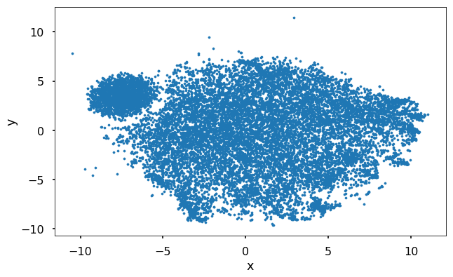

```python
# Display the layout of all of the points.
sns.set_context("poster")
points_doc.plot.scatter("x", "y", s=10, figsize=(10, 6))
```

```python
points_doc[points_doc.word == 'alice']
```

|  | word | x | y |
| --- | --- | --- | --- |
| 2365 | alice | 5.912175 | 0.401644 |

```python
model_doc.wv
```

```
<gensim.models.keyedvectors.Word2VecKeyedVectors at 0x223283898d0>
```

## Topic extraction

### Creating the term dictionary of easch book corpus, where every unique term is assigned an index.

```python
dictionary_alice = corpora.Dictionary(alice_fin_sent)
```

```python
dictionary_gulliver = corpora.Dictionary(gulliver_fin_sent)
```

```python
dictionary_swann = corpora.Dictionary(swann_fin_sent)
```

```python
three_books=[tales_fin_sent+sidd_fin_sent+mow_fin_sent]
```

```python
dictionary_all=corpora.Dictionary(all_fin_sent)
```

```python
dictionary_robinson = corpora.Dictionary(robinson_fin_sent)
```

```python
dictionary_tales = corpora.Dictionary(tales_fin_sent)
```

```python
dictionary_sidd = corpora.Dictionary(sidd_fin_sent)
```

```python
dictionary_mow = corpora.Dictionary(mow_fin_sent)
```

```python
dictionary_chem = corpora.Dictionary(chem_fin_sent)
```

```python
dictionary_google = corpora.Dictionary(google_fin_sent)
```

### Converting list of documents (corpus) into Document Term Matrix using dictionary prepared above.

```python
doc_term_matrix_alice = [dictionary_alice.doc2bow(doc) for doc in alice_fin_sent]
```

```python
doc_term_matrix_gulliver = [dictionary_gulliver.doc2bow(doc) for doc in gulliver_fin_sent]
```

```python
doc_term_matrix_swann = [dictionary_swann.doc2bow(doc) for doc in swann_fin_sent]
```

```python
doc_term_matrix_robinson = [dictionary_robinson.doc2bow(doc) for doc in robinson_fin_sent]
```

```python
doc_term_matrix_tales = [dictionary_tales.doc2bow(doc) for doc in tales_fin_sent]
```

```python
doc_term_matrix_sidd = [dictionary_sidd.doc2bow(doc) for doc in sidd_fin_sent]
```

```python
doc_term_matrix_mow = [dictionary_mow.doc2bow(doc) for doc in mow_fin_sent]
```

```python
doc_term_matrix_all = [dictionary_all.doc2bow(doc) for doc in all_fin_sent]
```

```python
doc_term_matrix_chem = [dictionary_chem.doc2bow(doc) for doc in chem_fin_sent]
```

```python
doc_term_matrix_google = [dictionary_google.doc2bow(doc) for doc in google_fin_sent]
```

### The Lda model

```python
Lda = gensim.models.ldamodel.LdaModel
```

```python
ldamodel_gulliver = Lda(doc_term_matrix_gulliver, num_topics=4, id2word = dictionary_gulliver, passes=150)
```

```python
ldamodel_alice = Lda(doc_term_matrix_alice, num_topics=3, id2word = dictionary_alice, passes=750)
```

```python
ldamodel_swann = Lda(doc_term_matrix_swann, num_topics=5, id2word = dictionary_swann, passes=150)
```

```python
ldamodel_robinson = Lda(doc_term_matrix_robinson, num_topics=5, id2word = dictionary_robinson, passes=350)
```

```python
ldamodel_tales = Lda(doc_term_matrix_tales, num_topics=5, id2word = dictionary_tales, passes=350)
```

```python
ldamodel_sidd = Lda(doc_term_matrix_sidd, num_topics=5, id2word = dictionary_sidd, passes=150)
```

```python
ldamodel_mow = Lda(doc_term_matrix_mow, num_topics=5, id2word = dictionary_mow, passes=800)
```

```python
ldamodel_chem = Lda(doc_term_matrix_chem, num_topics=6, id2word = dictionary_chem, passes=500)
```

```python
ldamodel_google = Lda(doc_term_matrix_google, num_topics=5, id2word = dictionary_google, passes=800)
```

```python
ldamodel_all = Lda(doc_term_matrix_all, num_topics=10, id2word = dictionary_all, passes=5)
```

```python
#max_books= all_word_vectors_matrix_2_d
with open(r"lda_model.pickle", "wb") as output_file:
    pickle.dump(ldamodel, output_file)
```

### Printing topics from the lda model usage

```python
alice_topics = ldamodel_alice.print_topics(num_words=5)
for topic in alice_topics:
    print(topic)
```

```
(0, '0.035*"said" + 0.031*"alice" + 0.013*"little" + 0.010*"king" + 0.009*"know"')
(1, '0.033*"alice" + 0.022*"said" + 0.011*"little" + 0.008*"got" + 0.008*"door"')
(2, '0.020*"alice" + 0.011*"one" + 0.010*"rabbit" + 0.009*"said" + 0.007*"large"')
```

```python
#print(ldamodel_gulliver.print_topics(num_topics=5, num_words=5))
gulliver_topics = ldamodel_gulliver.print_topics(num_words=5)
for topic in gulliver_topics:
    print(topic)
```

```
(0, '0.009*"would" + 0.008*"made" + 0.008*"could" + 0.006*"two" + 0.006*"upon"')
(1, '0.010*"one" + 0.010*"feet" + 0.006*"took" + 0.005*"two" + 0.005*"could"')
(2, '0.005*"great" + 0.004*"two" + 0.004*"made" + 0.004*"oats" + 0.004*"house"')
(3, '0.010*"would" + 0.010*"could" + 0.009*"upon" + 0.007*"country" + 0.007*"master"')
```

```python
swann_topics = ldamodel_swann.print_topics(num_words=8)
for topic in swann_topics:
    print(topic)
```

```
(0, '0.018*"would" + 0.007*"Swann" + 0.007*"upon" + 0.006*"What" + 0.006*"face" + 0.006*"time" + 0.005*"one" + 0.005*"room"')
(1, '0.012*"one" + 0.009*"like" + 0.008*"would" + 0.007*"I" + 0.005*"upon" + 0.005*"little" + 0.004*"still" + 0.004*"two"')
(2, '0.048*"I" + 0.022*"would" + 0.010*"one" + 0.008*"Swann" + 0.008*"Odette" + 0.007*"could" + 0.007*"And" + 0.007*"never"')
(3, '0.017*"Swann" + 0.015*"Mme" + 0.011*"Verdurin" + 0.009*"one" + 0.008*"de" + 0.007*"M" + 0.006*"little" + 0.005*"Odette"')
(4, '0.029*"I" + 0.006*"like" + 0.005*"would" + 0.004*"Fran" + 0.004*"But" + 0.004*"oise" + 0.003*"could" + 0.003*"words"')
```

```python
robinson_topics = ldamodel_robinson.print_topics(num_words=5)
for topic in robinson_topics:
    print(topic)
```

```
(0, '0.014*"would" + 0.012*"ship" + 0.010*"captain" + 0.010*"could" + 0.009*"upon"')
(1, '0.016*"upon" + 0.011*"could" + 0.011*"us" + 0.009*"one" + 0.009*"man"')
(2, '0.015*"account" + 0.014*"hundred" + 0.011*"one" + 0.011*"would" + 0.011*"two"')
(3, '0.021*"us" + 0.014*"would" + 0.014*"friday" + 0.012*"come" + 0.011*"bear"')
(4, '0.014*"boat" + 0.013*"shore" + 0.011*"two" + 0.011*"found" + 0.010*"ship"')
```

```python
tales_topics = ldamodel_tales.print_topics(num_words=5)
for topic in tales_topics:
    print(topic)
```

```
(0, '0.043*"said" + 0.013*"oh" + 0.010*"princess" + 0.009*"captain" + 0.009*"good"')
(1, '0.022*"lad" + 0.021*"said" + 0.017*"one" + 0.014*"came" + 0.013*"went"')
(2, '0.022*"said" + 0.020*"got" + 0.013*"came" + 0.012*"halvor" + 0.012*"man"')
(3, '0.017*"said" + 0.015*"could" + 0.014*"time" + 0.013*"one" + 0.013*"went"')
(4, '0.029*"said" + 0.021*"well" + 0.015*"must" + 0.011*"wind" + 0.011*"prince"')
```

```python
sidd_topics = ldamodel_sidd.print_topics(num_words=7)
for topic in sidd_topics:
    print(topic)
```

```
(0, '0.018*"saw" + 0.013*"siddhartha" + 0.011*"time" + 0.011*"many" + 0.010*"one" + 0.008*"felt" + 0.008*"good"')
(1, '0.010*"siddhartha" + 0.010*"face" + 0.008*"self" + 0.008*"kamala" + 0.006*"also" + 0.006*"become" + 0.006*"always"')
(2, '0.043*"siddhartha" + 0.018*"govinda" + 0.015*"river" + 0.014*"time" + 0.013*"said" + 0.011*"long" + 0.010*"would"')
(3, '0.026*"one" + 0.012*"siddhartha" + 0.010*"thus" + 0.008*"like" + 0.008*"thought" + 0.008*"govinda" + 0.008*"words"')
(4, '0.013*"like" + 0.012*"never" + 0.011*"siddhartha" + 0.009*"knew" + 0.008*"could" + 0.008*"also" + 0.007*"every"')
```

```python
mow_topics = ldamodel_mow.print_topics(num_words=3)
for topic in mow_topics:
    print(topic)
```

[output not shown]

```python
all_topics = ldamodel_all.print_topics(num_words=5)
for topic in all_topics:
    print(topic)
```

```
(0, '0.052*"pierre" + 0.032*"face" + 0.029*"room" + 0.023*"yes" + 0.021*"catherine"')
(1, '0.020*"could" + 0.015*"would" + 0.014*"began" + 0.014*"one" + 0.013*"nothing"')
(2, '0.027*"andrew" + 0.018*"nicholas" + 0.017*"master" + 0.015*"side" + 0.012*"two"')
(3, '0.028*"asked" + 0.023*"though" + 0.013*"countess" + 0.013*"god" + 0.012*"heart"')
(4, '0.075*"said" + 0.021*"sha" + 0.020*"nat" + 0.015*"head" + 0.014*"seemed"')
(5, '0.020*"french" + 0.018*"thought" + 0.016*"love" + 0.013*"never" + 0.012*"would"')
(6, '0.035*"prince" + 0.023*"men" + 0.019*"say" + 0.014*"see" + 0.014*"napoleon"')
(7, '0.024*"v" + 0.018*"army" + 0.017*"chapter" + 0.013*"kut" + 0.013*"zov"')
(8, '0.024*"would" + 0.021*"go" + 0.021*"come" + 0.016*"us" + 0.016*"day"')
(9, '0.018*"man" + 0.016*"went" + 0.014*"eyes" + 0.014*"one" + 0.012*"old"')
```

```python
chem_topics = ldamodel_chem.print_topics(num_words=4)
for topic in chem_topics:
    print(topic)
```

```
(0, '0.013*"food" + 0.010*"proteid" + 0.009*"water" + 0.008*"matter"')
(1, '0.016*"acid" + 0.013*"uric" + 0.012*"food" + 0.008*"less"')
(2, '0.011*"food" + 0.010*"foods" + 0.009*"salt" + 0.008*"flesh"')
(3, '0.014*"food" + 0.013*"meat" + 0.009*"per" + 0.008*"flesh"')
(4, '0.024*"food" + 0.014*"quantity" + 0.011*"foods" + 0.008*"body"')
(5, '0.019*"food" + 0.007*"milk" + 0.006*"one" + 0.006*"much"')
```

```python
google_topics = ldamodel_google.print_topics(num_words=7)
for topic in google_topics:
    print(topic)
```

```
(0, '0.031*"terms" + 0.030*"adobe" + 0.020*"software" + 0.020*"use" + 0.020*"sublicensee" + 0.019*"shall" + 0.017*"may"')
(1, '0.030*"sublicensee" + 0.028*"terms" + 0.021*"google" + 0.020*"adobe" + 0.018*"rights" + 0.013*"additional" + 0.012*"may"')
(2, '0.035*"adobe" + 0.028*"software" + 0.018*"video" + 0.018*"code" + 0.017*"content" + 0.014*"may" + 0.013*"avc"')
(3, '0.071*"google" + 0.032*"terms" + 0.027*"services" + 0.020*"agreement" + 0.018*"adobe" + 0.018*"chrome" + 0.014*"content"')
(4, '0.046*"google" + 0.038*"services" + 0.023*"may" + 0.021*"use" + 0.019*"software" + 0.017*"adobe" + 0.017*"sublicensee"')
```